# Reproducible Research: Peer Assessment 1

### Loading and preprocessing the data

```r
activity.data <- read.csv("activity.csv", stringsAsFactors=F)
```

### What is mean total number of steps taken per day?

Make a histogram of the total number of steps taken each day

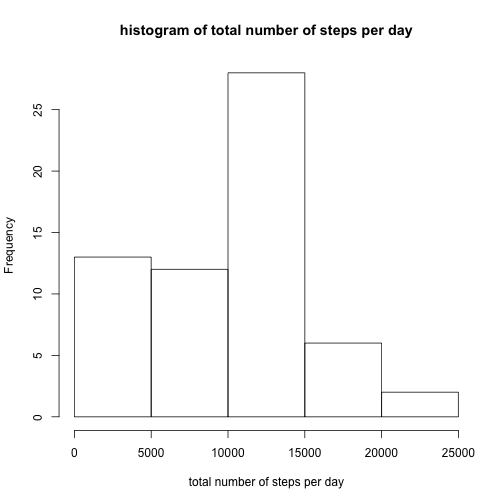

```r
# for each factor (ie date), sum steps, ignore any NAs
library(plyr)
data <- ddply(activity.data, .(date), summarize, total.steps.per.day=sum(steps,na.rm=T))

hist(data$total.steps.per.day, xlab="total number of steps per day", main="histogram of total number of steps per day")
```

mean total number of steps taken per day

```r
mean(data$total.steps.per.day, na.rm=T)
```

```
## [1] 9354
```

median total number of steps taken per day

```r
median(data$total.steps.per.day, na.rm=T)
```

```
## [1] 10395
```

### What is the average daily activity pattern?

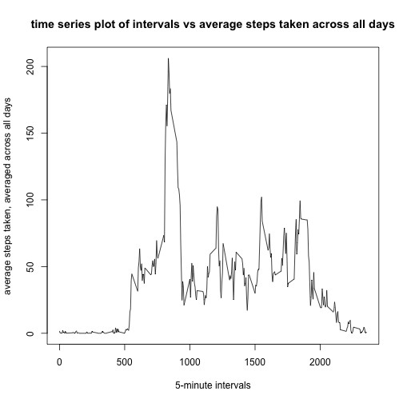

```r
#for each factor (ie interval), report average of steps across all days
average.steps.per.interval.data <- ddply(activity.data, .(interval), summarize, average.steps.across.all.days=mean(steps, na.rm=T))

plot(average.steps.per.interval.data$interval, average.steps.per.interval.data$average.steps.across.all.days, type="l", xlab="5-minute intervals", ylab="average steps taken, averaged across all days", main="time series plot of intervals vs average steps taken across all days")
```

The following 5-minute interval, on average across all the days in the dataset, contains the maximum number of steps

```r
average.steps.per.interval.data[(average.steps.per.interval.data$average.steps.across.all.days==max(average.steps.per.interval.data$average.steps.across.all.days)),]$interval
```

```
## [1] 835
```

### Imputing missing values

the total number of missing values in the dataset

```r
nrow(activity.data[(is.na(activity.data$steps)),])
```

```
## [1] 2304
```

fill in all of the missing values in the dataset by using the mean for that 5-minute interval, etc.

```r
# keep a copy of the original dataset before imputing the missing values
original.activity.data <- activity.data

# for each corresponding interval with missing steps match it up to its average-steps-per-interval value.
missing.imputed.values <- average.steps.per.interval.data[match(activity.data[(is.na(activity.data$steps)),]$interval, average.steps.per.interval.data$interval),]$average.steps.across.all.days
activity.data[(is.na(activity.data$steps)),]$steps <- missing.imputed.values
```

Make a histogram of the total number of steps taken each day

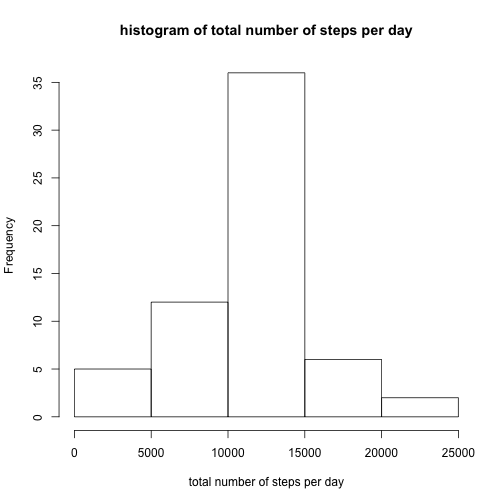

```r
# for each factor (ie date), sum steps, na.rm=T
#total.nr.of.steps.per.day <- aggregate(activity.data$steps, list(date = activity.data$date), sum, na.rm=T)$x
data <- ddply(activity.data, .(date), summarize, total.steps.per.day=sum(steps,na.rm=T))

hist(data$total.steps.per.day, xlab="total number of steps per day", main="histogram of total number of steps per day")
```

mean number of steps taken per day

```r
mean(data$total.steps.per.day, na.rm=T)
```

```
## [1] 10766
```

median number of steps taken per day

```r
median(data$total.steps.per.day, na.rm=T)
```

```
## [1] 10766
```

The values for the mean and median differ from the estimates from the first part of the assignment. By imputing missing data on the estimates of the total daily number of steps, the mean and median values converge to the same value and are higher than before.

### Are there differences in activity patterns between weekdays and weekends?

Create a new factor variable in the dataset with two levels – “weekday” and “weekend” indicating whether a given date is a weekday or weekend day

```r
activity.data$weektime <- weekdays(as.Date(activity.data$date))
activity.data[(activity.data$weektime %in% c("Saturday", "Sunday")),]$weektime <- "weekend"
activity.data[(!(activity.data$weektime %in% c("weekend"))),]$weektime <- "weekday"

activity.data$weektime <- as.factor(activity.data$weektime)
```

Make a panel plot containing a time series plot (i.e. type = “l”) of the 5-minute interval (x-axis) and the average number of steps taken, averaged across all weekday days or weekend days (y-axis).

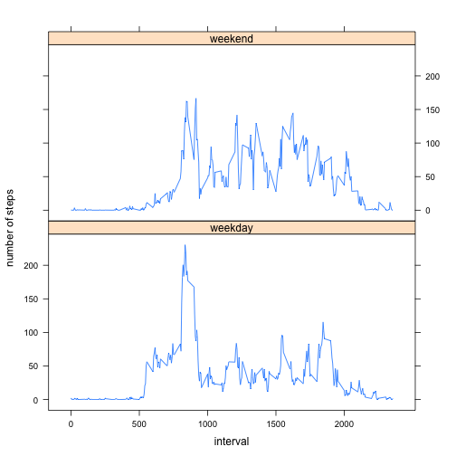

```r
data <- ddply(activity.data, .(interval, weektime), summarize, nr.of.steps=mean(steps,na.rm=T))

library(lattice)
xyplot(nr.of.steps~interval|weektime, data = data, type = "l", scales=list(x=list(at=seq(0, 2000, by=500))), layout=c(1,2), xlab="interval", ylab="number of steps")
```

From this plot, there is a difference in activity patterns between weekdays and weekends. Weekends have more intervals with more activity while weekdays have fewer intervals with higher levels of activity.